# Quadratic Spline Interpolation of Fertility Schedules

Carl Schmertmann

29 Nov 2018

## Purpose

Illustrates least-squares fitting of Quadratic Spline (QS) model to several examples of $_{1}f_x$ schedules from the HFD. The QS model is described in

CP Schmertmann, 2003. *A System of Model Fertility Schedules with Graphically Intuitive Parameters*. **Demographic Research** Vol. 9-5 (10 Oct 2003). https://dx.doi.org/10.4054/DemRes.2003.9.5

The main idea is to find a continuous function (specifically, a restricted quadratic spline) that approximates the observed $f_x$ values. A QS curve has four parameters:

1. $R$ : the peak level of fertility
2. $\alpha$ : the lowest age at which fertility is positive
3. $P$ : the age at which fertility reaches its peak value $R$
4. $H$ : the age $>P$ at which fertility falls to half its peak value, $R/2$.

**This version** of the program uses the *nls()* function in R.

## Download and prepare several $_{1}f_x$ schedules from the HFD

```r
HFD  = read.table("asfrRR.txt",skip=2, header=TRUE)

HFD$Age   = 12:55  ## make numeric
HFD$sched = paste0(HFD$Code, HFD$Year)

HFDmatrix = matrix(HFD$ASFR, nrow=44,
                   dimnames=list(12:55, unique(HFD$sched)))


# display the first few
print( HFDmatrix[, 1:5])
```

```
##    AUT1951 AUT1952 AUT1953 AUT1954 AUT1955
## 12 0.00000 0.00000 0.00000 0.00000 0.00002
## 13 0.00000 0.00004 0.00004 0.00002 0.00003
## 14 0.00037 0.00038 0.00033 0.00018 0.00003
## 15 0.00150 0.00171 0.00188 0.00204 0.00219
## 16 0.00846 0.00816 0.00881 0.00894 0.00963
## 17 0.02615 0.02519 0.02523 0.02773 0.02750
## 18 0.05113 0.05052 0.05062 0.05217 0.05747
## 19 0.07838 0.08222 0.08029 0.08006 0.08610
## 20 0.10010 0.10226 0.10696 0.10948 0.11072
## 21 0.11041 0.11361 0.12003 0.12211 0.12869
## 22 0.11919 0.12334 0.12885 0.13298 0.14012
## 23 0.12044 0.12349 0.12787 0.13456 0.14761
## 24 0.12267 0.12821 0.13171 0.13642 0.14409
## 25 0.12121 0.12386 0.13080 0.13507 0.14408
```

[output cut: 30 more lines]

## Identify (1) the fine grid of ages for the QS function, (2) the lowest ages in each age group for which we have nFa data, and (3) the width $n$ of each age interval

```r
## grid of ages for QS
delta = .25
x = seq(from= 12+delta/2, to= 56-delta/2, by=delta)

## low ends of age intervals
a = seq(from=12, to=55, by=1)

## age interval width
n = 1

## calculate translation matrix G such that G %*% QS() = grouped rates
tmp = outer( a, x, function(a,x) { 1*(x>=a)*(x <= (a+n)) })
G   = prop.table(tmp,1)
```

## Define the $QS(\:)$ function

$x$ is the vector of ages at which to calculate interpolated rates

```r
QS = function(R=.20,alpha=15,P=28,H=34) {

  w = min(.75, .25+.025*(P-alpha))
  beta = max (  min(50, 4*H-3*P) , (4*H-P)/3 )

  D = P-20          # delay index
  C = (P+50)/2 - H  # control index

  knot    = vector("numeric",5)
  knot[1] = alpha
  knot[2] = alpha + w*(P-alpha)
  knot[3] = P
  knot[4] = (P+H)/2
  knot[5] = (H+beta)/2

  A      = matrix(NA,5,5)
  target = vector("numeric",5)

  # target value at P=1
  A[1,]     = (pmax(P-knot, 0))^2
  target[1] = 1

  # target value at H=1/2
  A[2,]     = (pmax(H-knot, 0))^2
  target[2] = 1/2

  # target value at beta=0
  A[3,]     = (pmax(beta-knot, 0))^2
  target[3] = 0

  # target slope at P=0
  A[4,]     = 2*pmax(P-knot, 0)
  target[4] = 0

  # target slope at beta=0
  A[5,]     = 2*pmax(beta-knot, 0)
  target[5] = 0

  # calculate thetas
  theta = solve(A,target)

  tmp = (pmax( outer(x,knot,"-") , 0))^2

  y = (x >= alpha) * (x <= beta) * R * (tmp %*% theta)  # ASFRs

  return(as.vector(y) )

} #QS
```

[output not shown]

## Calculate and plot least-squares estimates of QS parameters for 50 random HFD schedules

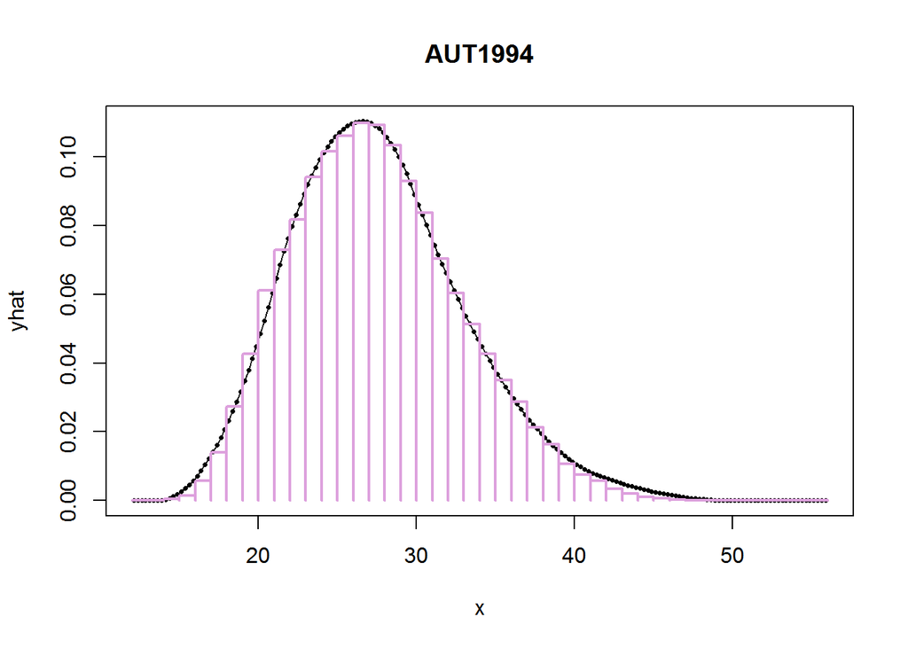

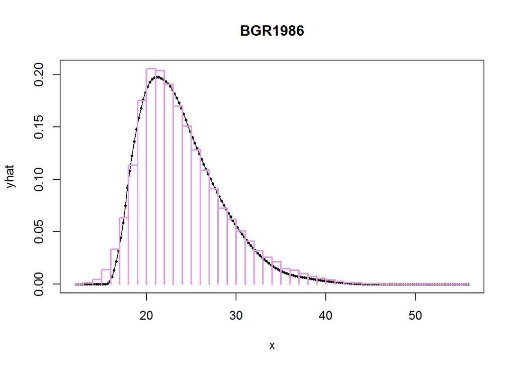

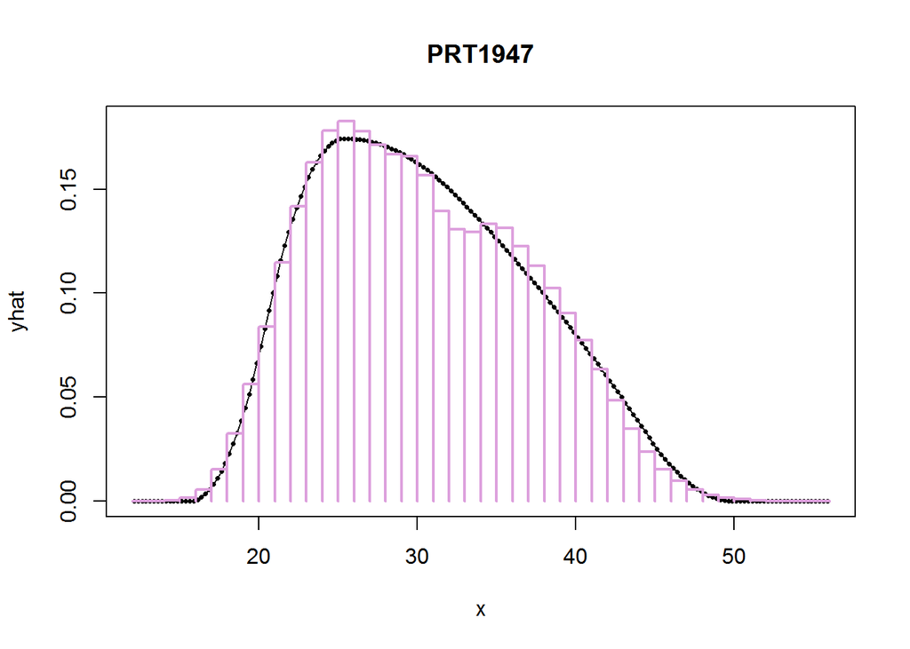

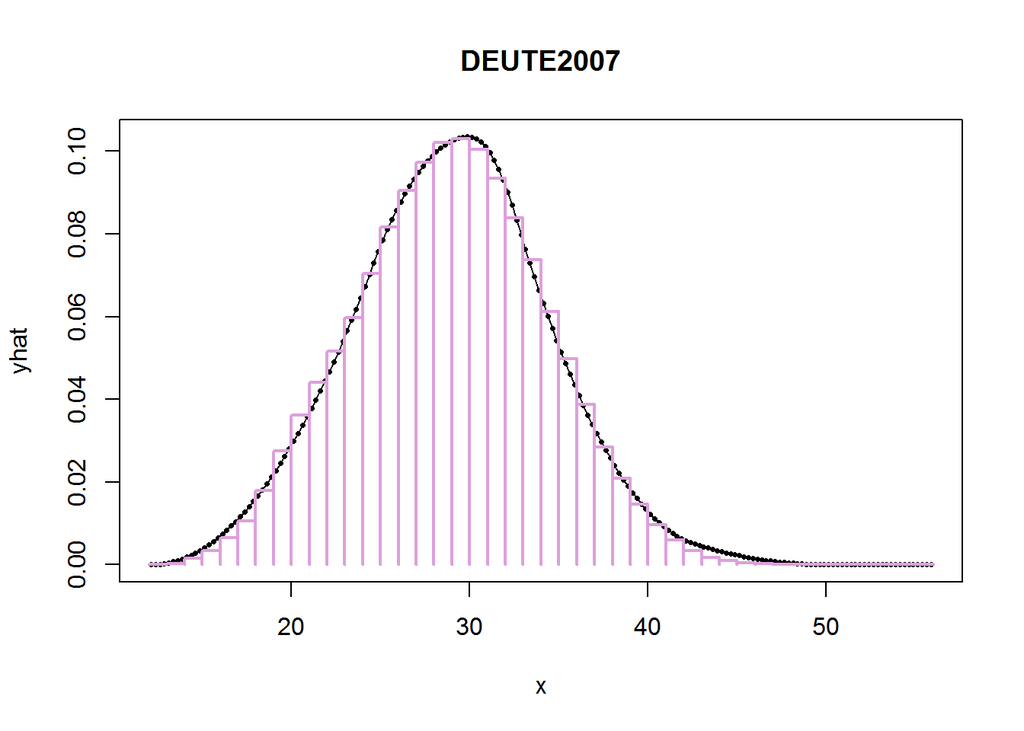

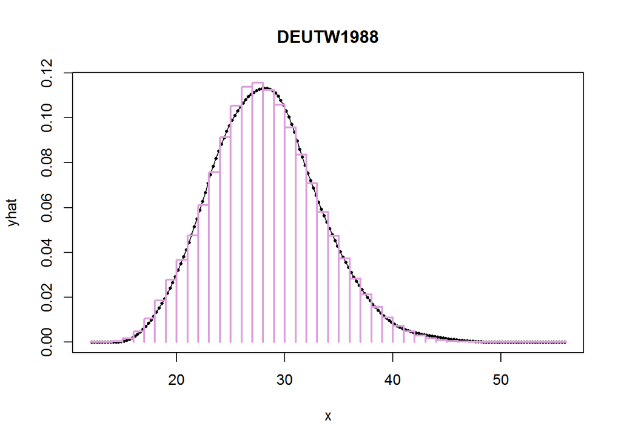

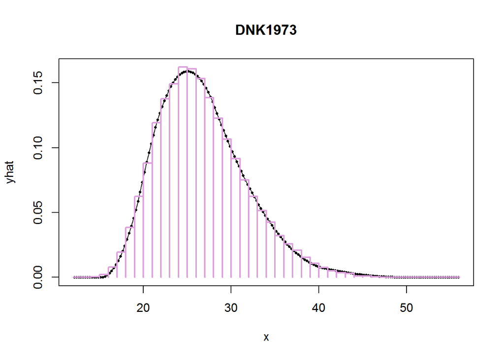

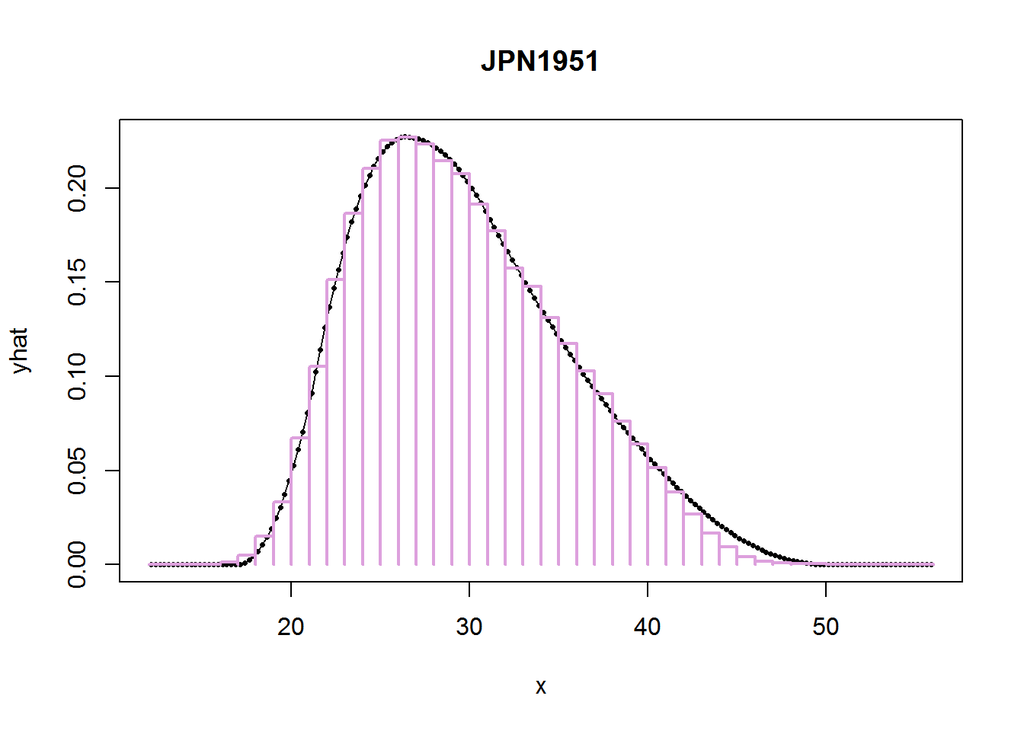

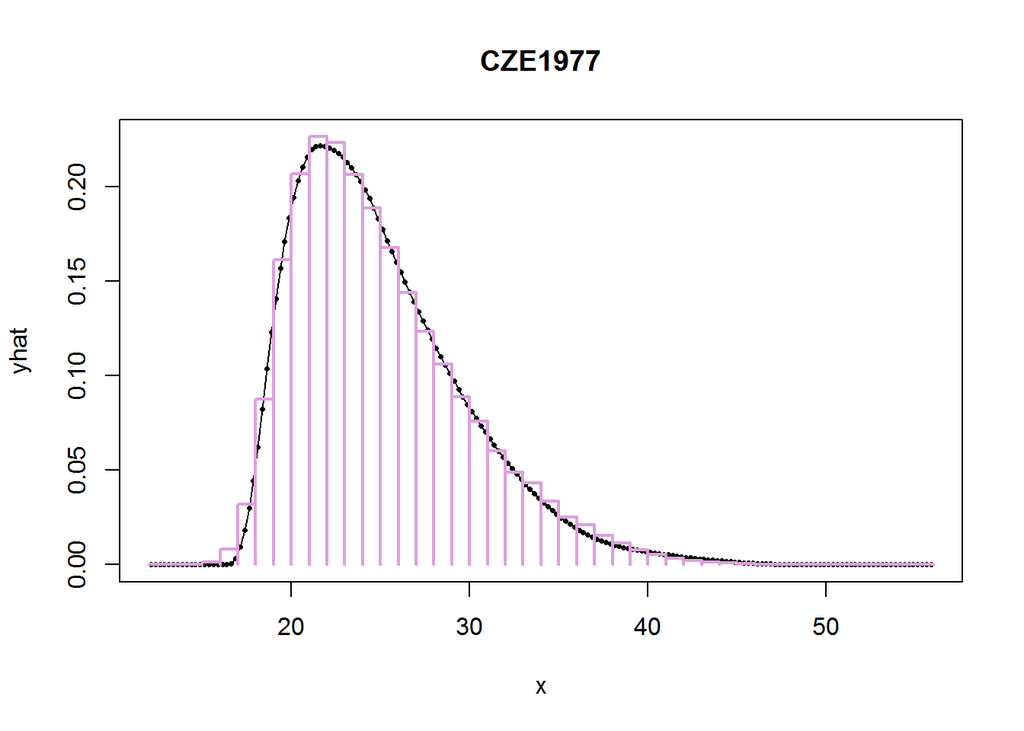

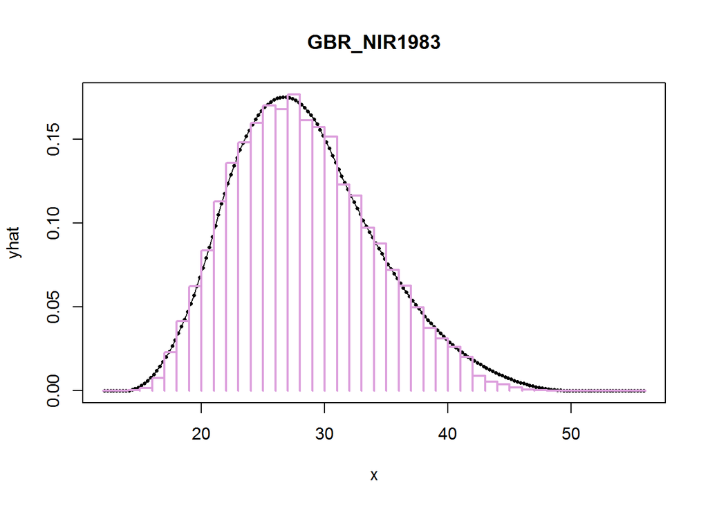

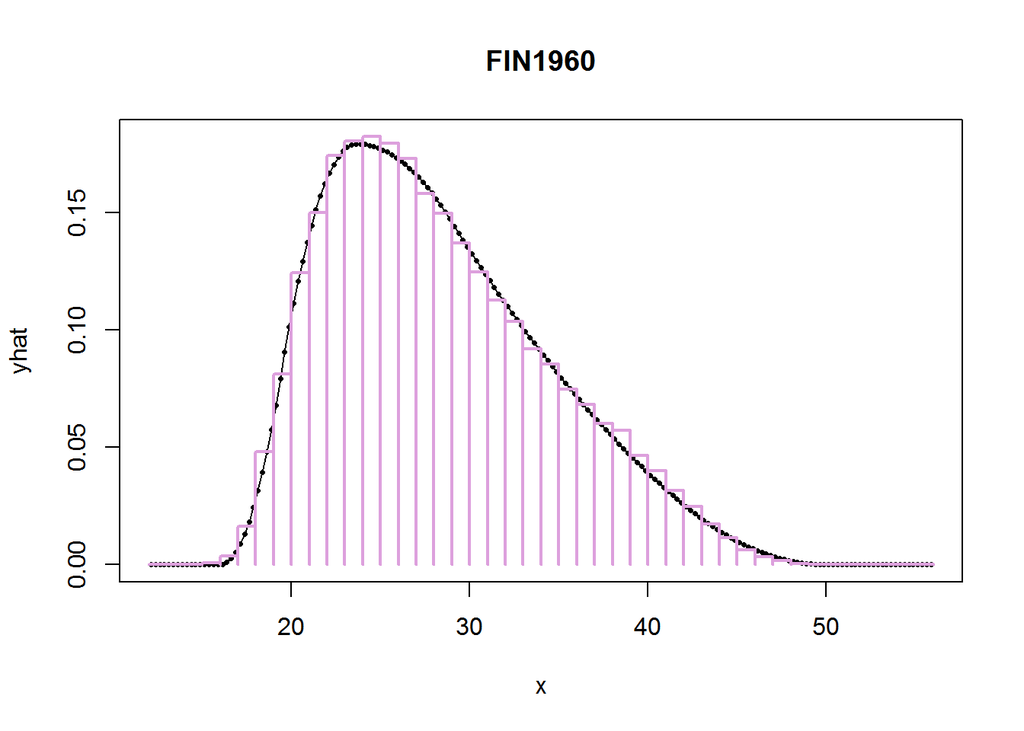

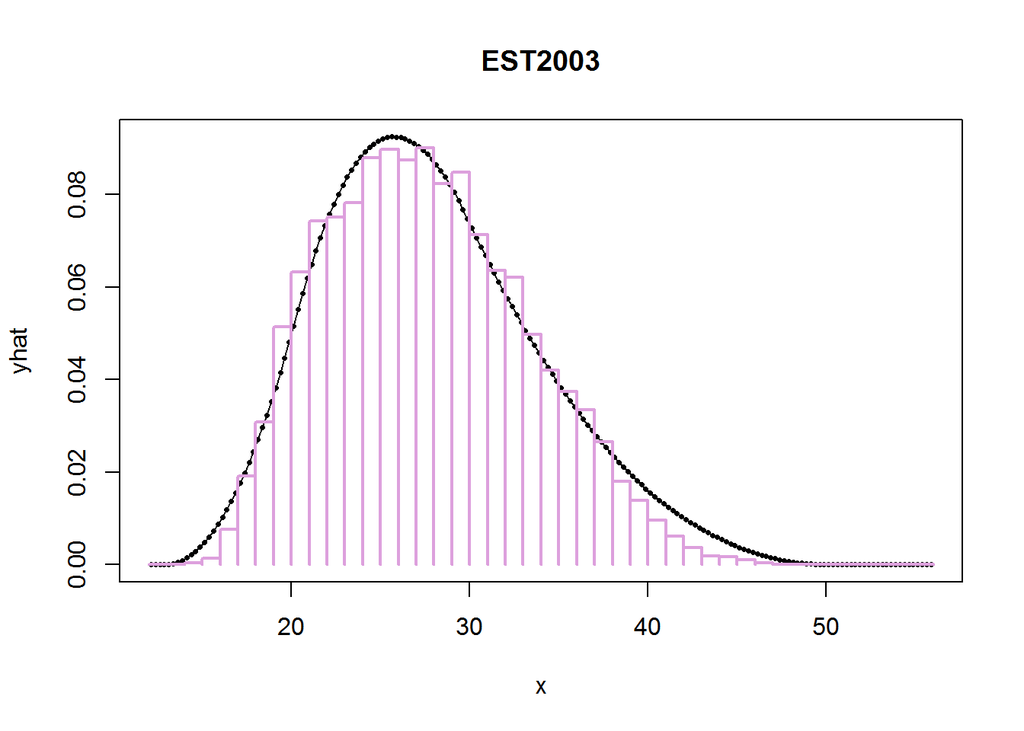

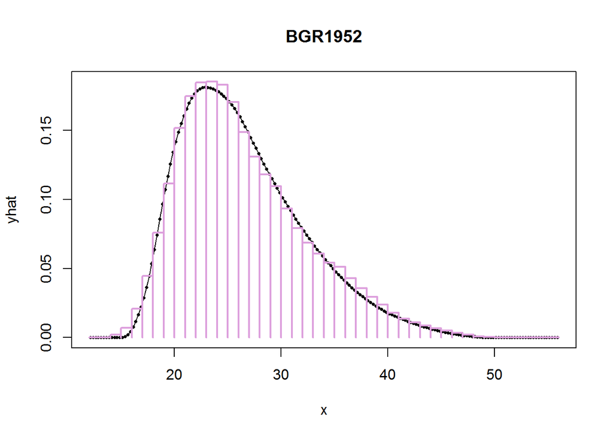

[38 more figures not shown]

```r
#####################
selected_schedules = sample( colnames(HFDmatrix), 50)

error_formula = formula( fx ~ I( G %*% QS(R,alpha,P,H) ) )

for (this_schedule in selected_schedules) {

  try({
    fx <- HFDmatrix[, this_schedule]

    ## INITIAL ESTIMATES OF PARAMETERS using MAC for P
    midage <- 12:55 + 0.5
    mac   <- sum(fx*midage)/sum(fx)
    init_param <- c(alpha=15,R=max(fx),P=mac, H=(mac+50)/2)


    ## find optimal R, P & H params for QS
    this.result <- nls(error_formula, start=init_param)

    results = rbind(results,
                    data.frame(sched  = this_schedule,
                               alpha  = round(coef(this.result)['alpha'],2),
                               R      = round(coef(this.result)['R'],2),
                               P      = round(coef(this.result)['P'],2),
                               H      = round(coef(this.result)['H'],2),2)
                    )


    #-------- plot --------------
    yhat   = QS(alpha= coef(this.result)['alpha'],
                R    = coef(this.result)['R'],
                P    = coef(this.result)['P'],
                H    = coef(this.result)['H'])

    plot( x, yhat, type='o', main=this_schedule, pch=16, cex=.50,
          ylim=range(0,yhat,fx))

    segments(a,    fx, a+n, fx, col='plum', lwd=2)
    segments(a,     0, a  , fx, col='plum', lwd=2)
    segments(a+n,   0, a+n, fx, col='plum', lwd=2)

  })
} # for this_schedule
```

## Display the parameter estimates that correspond to the graphs

```r
rownames(results) = NULL
results
```

```
##          sched alpha    R     P     H X2
## 1      AUT1994 13.62 0.11 26.57 32.97  2
## 2      BGR1986 15.47 0.20 21.07 27.21  2
## 3      PRT1947 15.66 0.17 25.40 39.26  2
## 4    DEUTE2007 12.17 0.10 29.96 35.09  2
## 5    DEUTW1988 14.47 0.11 28.24 33.60  2
## 6      DNK1973 15.15 0.16 25.03 31.31  2
## 7      JPN1951 16.96 0.23 26.40 35.50  2
## 8      CZE1977 16.49 0.22 21.53 28.33  2
## 9  GBR_NIR1983 13.82 0.18 26.70 34.17  2
## 10     FIN1960 16.00 0.18 23.64 34.09  2
## 11     EST2003 12.92 0.09 25.70 33.80  2
## 12     BGR1952 15.06 0.18 22.83 30.97  2
## 13 GBRTENW1967 14.26 0.19 24.41 32.29  2
## 14     CHE2015 15.86 0.12 33.08 37.86  2
```

[output cut: 36 more lines]